# $z^i_gz^a_g$ quick start guide

Ammon Thompson

July 9, 2019

### Install zigzag

Navigate to a directory where you would like to install the zigzag repository that contains the R package, zigzag.

```bash
bash
git clone https://github.com/ammonthompson/zigzag.git
```

To install the R package, open an R terminal or in the console in Rstudio, type: (if your working directory is not where the zigzag package is, then include the path to zigzag). The package is a directory that contains the .Rproj and DESCRIPTION files.

```r
R
install.packages("zigzag", type = "source", repos = NULL)
require(zigzag)
```

Note, zigzag depends on R packages coda and matrixStates.

### Load Expression and Gene Length Data

After cloning the zigzag repository and instaling the zigzag R package, open R and set the quick_start_guide directory to your working directory. We have provided example data for this tutorial. These are subsets of genes used in the zigzag publication (cation). You can copy-and-paste the R code to run analyses.

The expression data is found in the quick_start_guide directory. These files contain the TPM levels of 5,000 genes estimated in 4 human lung RNA-seq libraries from the GTEx dataset.

```r
expression_data = read.table("example_lung.tpm", header = T, row.names = 1)

head(round(expression_data, digits = 1))
```

```
##                 Lib_1 Lib_2 Lib_3 Lib_4
## ENSG00000127720   1.5   3.3   4.1   5.0
## ENSG00000256574   0.2   1.0   0.4   0.1
## ENSG00000109819   1.7   3.3   2.3   1.9
## ENSG00000161057  42.8  53.3  44.2  48.9
## ENSG00000237787   0.0   0.0   0.0   0.0
## ENSG00000051596   2.8   3.0   6.1   5.6
```

zigzag requires the data contain row names which are gene names and column names which are the RNA sample labels. Ensure the row names correspond in the gene length and expression files.

```r
human_gene_lengths = read.table("example_gene_length.txt", header = T, row.names = 1)

head(round(human_gene_lengths, digits = 1))
```

```
##                 gene_length
## ENSG00000127720       872.5
## ENSG00000256574      1756.3
## ENSG00000109819      1391.7
## ENSG00000161057      1335.7
## ENSG00000237787       577.0
## ENSG00000051596       767.0
```

### Examine transcriptome distribution

The model used in zigzag assumes the transcriptome distribution is approximately bimodal and that each sub-distribution is approximately Normal, i.e. symmetrical bell-shaped distributions on the log-scale.

It is a good idea to check the densities of all libraries to make sure all libraries conform to the assumption of bimodal normal distributions. The vertical lines below indicate boundaries I have chosen for setting component mean prior thresholds. You can perform multiple analyses assuming different prior distributions with different boundaries to determine posterior sensitivity of the parameters of interest.

The thick blue line on the left shows an example upper and lower boundary for the prior on the inactive mean and the main active distribution respectively. The thin red line on the right shows the chosen lower boundary for a possible minor subpopulation of genes with high expression in the right tail of the distribution.

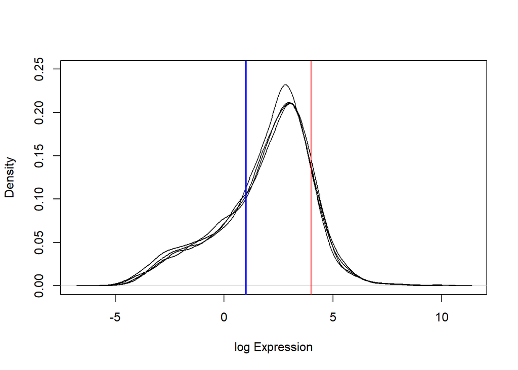

```r
plot(density(log(expression_data[,1])), main ="", xlab = "log Expression", ylim = c(0, 0.25))

for(i in seq(ncol(expression_data))) lines(density(log(expression_data[,i])))

abline(v = c(1, 4), lwd = c(2, 1), col = c("blue", "red"))
```

### Load data and set priors in a zigzag object

zigzag objects are of class type R6. Their member variables and methods are called with the $ symbol. Genererically methods and variables are called as object$method(), or object$variable.

We will next load the data into a zigzag object that specifies a mixture model that contains two subdistributions in the active expression component with boundaries set at 1 and 4 using the threshold_a flag: threshold_a = c(1, 4). The upper threshold for the inactive mean prior is by default equal to the threshold_a[1]. All other priors we will keep the default settings. Alternatively, ordered offsets for the means can be specified by only setting one lower threshold for the active compontnents: threshold_a = 1. To see all zigzag variables and default settings including hyperpriors type ?zigzag in the R consol.

```r
my_zigzag = zigzag$new(data = expression_data, gene_length = human_gene_lengths,
                       output_directory = "my_zigzag_output",
                       num_active_components = 2, threshold_a = c(1, 4))
```

When the zigzag object is created, the hyperprior settings will be summarized in a file in your output_directory, in this case my_zigzag_output/hyperparameter_settings.txt

### Run Burnin and assess convergence with log files

```r
my_zigzag$burnin(sample_frequency = 50, progress_plot = TRUE, write_to_files = TRUE, ngen=5000)
```

evaluate the burnin log files to determine if the chain has converged to the stationary distribution. The plot of sampled parameter values should randomly vary around a constant.

```r
burn = read.table("example_zigzag_output/output_burnin/output_model_parameters.log",
                  header = T, row.names =1)
```

If you interrupt the burnin, when you call the burnin function again it will start from where you left off.

```r
for(i in seq(ncol(burn))) plot(burn[,i], type = "l", main = colnames(burn)[i])
```

For example, the variable s0 appears to have converged on the stationary distribution around -2:

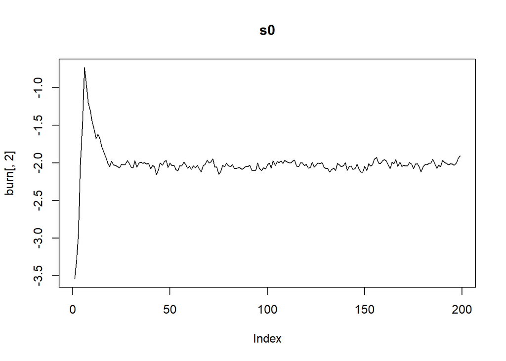

```r
plot(burn[,2], type = "l", main = colnames(burn)[2])
```

If satisfied all parameters have converged, proceed to run the mcmc. Type ?mcmc for more details.

### Run MCMC

To sample from the posterior distribution fun the mcmc function.

```r
my_zigzag$mcmc(sample_frequency = 50, ngen = 10000, mcmcprefix = "human_lung")
```

### Output files

Assess MCMC behavior.

```r
post = read.table("example_zigzag_output/example_lung_mcmc_output/example_lung_model_parameters.log",
                  header = T, row.names = 1)
```

To plot all parameter mcmc chains:

```r
for(i in seq(ncol(post))) plot(post[,i], type = "l", main = colnames(post)[i])
```

For example, s0 doesn’t appear to shift or drift from a stable distribution around -2:

```r
plot(post[,2], type = "l", main = colnames(post)[2])
```

[output not shown]

The probability each gene in the data is actively expressed is in the file: example_lung_probability_active.tab

```r
prob_active = read.table("example_zigzag_output/example_lung_mcmc_output/example_lung_probability_active.tab",
                header = T, row.names = 1)

head(round(prob_active, digits = 2))
```

```
##                 prob_active
## ENSG00000127720        0.78
## ENSG00000256574        0.04
## ENSG00000109819        0.68
## ENSG00000161057        1.00
## ENSG00000237787        0.00
## ENSG00000051596        0.88
```

Finally, you will want to create at least 2 zigzag objects and run two independent MCMC’s and confirm they converge on the same stationary distribution for all parameters and produce the same estimates of the probability of active expression for all genes.